# Inactive customer

### 1.2 Giai đoạn 2

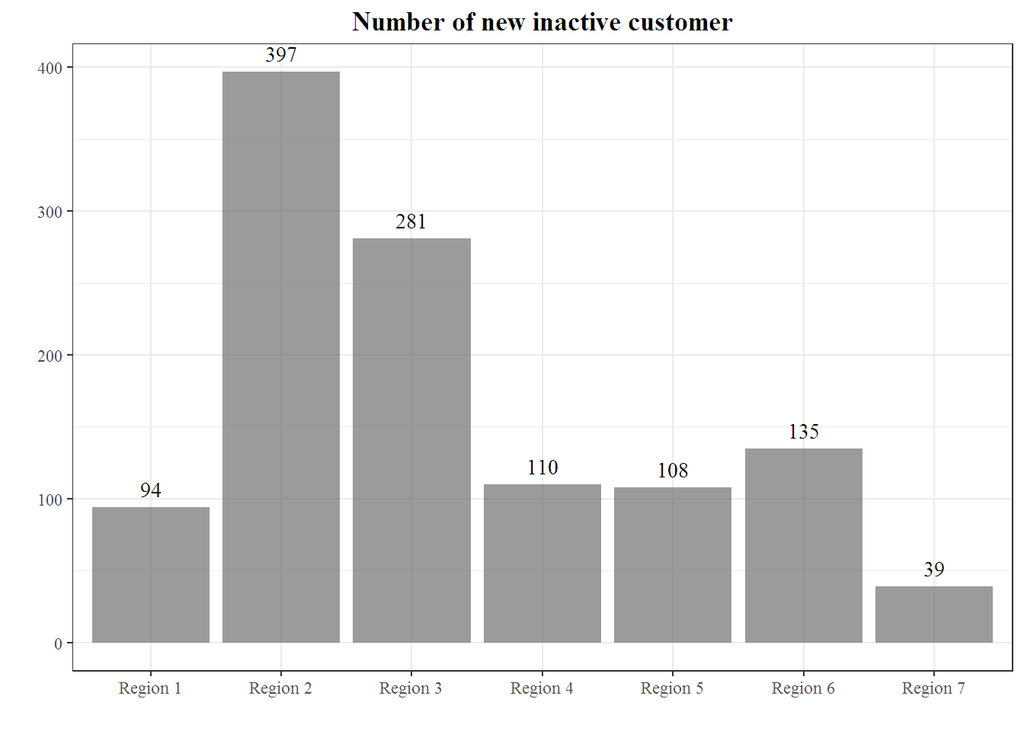

```r
cus.inactive.melt.inactive.201504 <- cus.inactive.melt.inactive %>% filter(Index =="STATUS_201504")
cus.inactive.melt.inactive.201505 <- cus.inactive.melt.inactive %>% filter(Index =="STATUS_201505")

cus.inactive.melt.inactive.201505 %>%
  left_join(cus.inactive.melt.inactive.201504,by = c("CIF" = "CIF")) %>%
  as.data.frame() %>%
  filter(is.na(Number.y)) %>%
  as.data.frame() %>%
  filter(REGION.x !="UNALLOCATED") %>%
  as.data.frame() %>%
  group_by(REGION.x) %>%
  summarise(number = n()) %>%
  ggplot(aes(REGION.x,number))+
  geom_bar(stat = "identity",alpha =0.6)+
  geom_text(aes(label = number),vjust = -0.7, family = "serif")+
  theme_bw()+
  theme(title = element_text(family = "serif",face = "bold"),
        axis.text = element_text(family = "serif"),
         plot.title = element_text(hjust = 0.5)
        )+
  labs(title = "Number of new inactive customer",
       x = "",
       y = "")+
  scale_x_discrete(labels = c("REGION 1" = "Region 1","REGION 2" = "Region 2","REGION 3" = "Region 3",
                              "REGION 4" = "Region 4","REGION 5" = "Region 5","REGION 6" = "Region 6",
                              "REGION 7" = "Region 7")
                   )
```

### 1.3 Giai đoạn 3

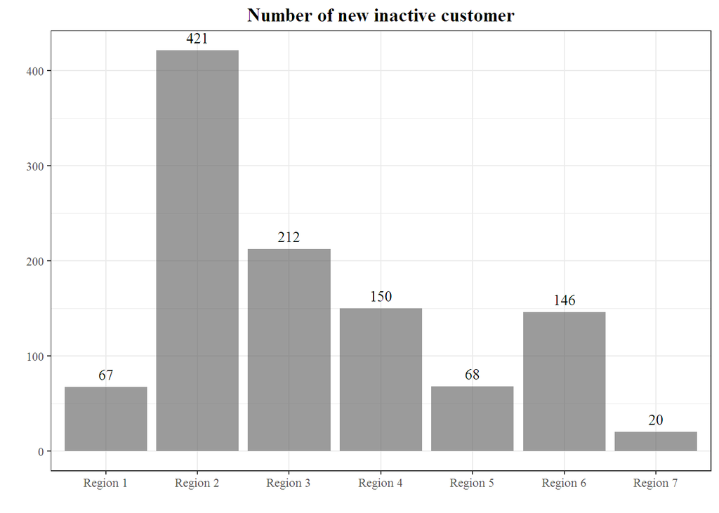

```r
cus.inactive.melt.inactive.201507 <- cus.inactive.melt.inactive %>% filter(Index =="STATUS_201507")
cus.inactive.melt.inactive.201508 <- cus.inactive.melt.inactive %>% filter(Index =="STATUS_201508")

cus.inactive.melt.inactive.201508 %>%
  left_join(cus.inactive.melt.inactive.201507,by = c("CIF" = "CIF")) %>%
  as.data.frame() %>%
  filter(is.na(Number.y)) %>%
  as.data.frame() %>%
  filter(REGION.x !="UNALLOCATED") %>%
  as.data.frame() %>%
  group_by(REGION.x) %>%
  summarise(number = n()) %>%
  ggplot(aes(REGION.x,number))+
  geom_bar(stat = "identity",alpha =0.6)+
  geom_text(aes(label = number),vjust = -0.7, family = "serif")+
  theme_bw()+
  theme(title = element_text(family = "serif",face = "bold"),
        axis.text = element_text(family = "serif"),
         plot.title = element_text(hjust = 0.5)
        )+
  labs(title = "Number of new inactive customer",
       x = "",
       y = "")+
  scale_x_discrete(labels = c("REGION 1" = "Region 1","REGION 2" = "Region 2","REGION 3" = "Region 3",
                              "REGION 4" = "Region 4","REGION 5" = "Region 5","REGION 6" = "Region 6",
                              "REGION 7" = "Region 7")
                   )
```

## 1.3. Kiểm định ANOVA

### 1.3.1 Trước và sau khi phân lại SME

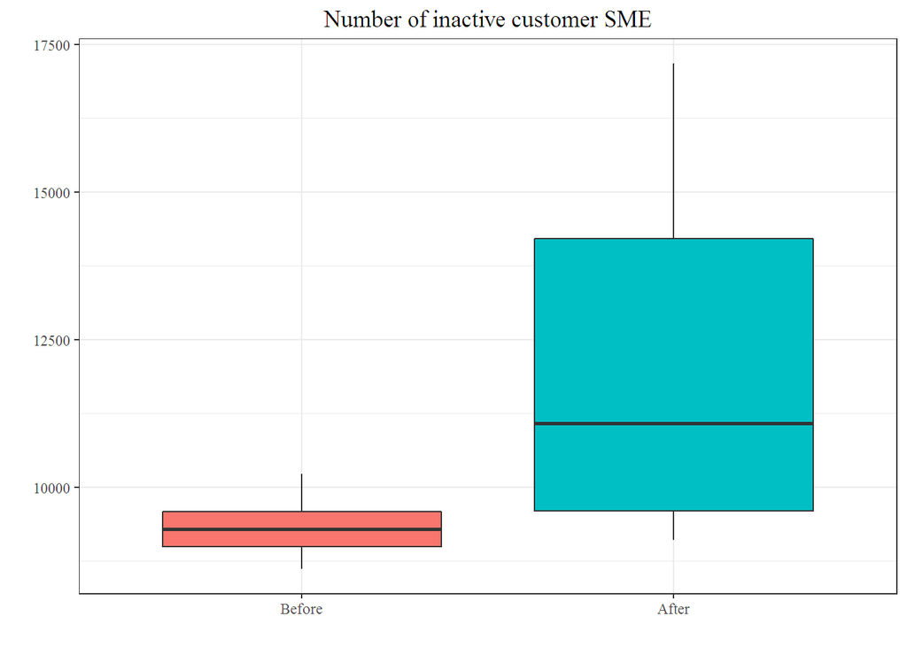

```r
SME <- cus.inactive.melt.inactive %>%
  filter(region_name %in% c("VUNG 01","VUNG 02","VUNG 05","VUNG 06","VUNG 03",
                            "VUNG 04","VUNG 07")) %>%
  group_by(Index,SME) %>%
  summarise(number = n())

SME %>%
  ggplot(aes(SME,number,fill = SME))+
  geom_boxplot()+
  theme_bw()+
  theme(legend.position = "none",
        title = element_text(family = "serif"),
        axis.text = element_text(family = "serif"),
        plot.title = element_text(hjust = 0.5))+
  scale_x_discrete(labels = c("0" = "Before","1" = "After"))+
  labs(x= "",
       y= "",
       title = "Number of inactive customer SME")
```

```r
SME %>% group_by(SME) %>% summarise(mean = mean(number))
```

```
## Source: local data frame [2 x 2]
##
##      SME     mean
##   (fctr)    (dbl)
## 1      0  9297.75
## 2      1 11974.83
```

```r
fit.sme <- aov(number~SME,data = SME)
fit.sme %>% summary()
```

```
##             Df    Sum Sq  Mean Sq F value  Pr(>F)
## SME          1  57334201 57334201   11.03 0.00215 **
## Residuals   34 176717182  5197564
## ---
## Signif. codes:  0 '***' 0.001 '**' 0.01 '*' 0.05 '.' 0.1 ' ' 1
```

```r
fit.sme %>% TukeyHSD()
```

```
##   Tukey multiple comparisons of means
##     95% family-wise confidence level
##
## Fit: aov(formula = number ~ SME, data = SME)
##
## $SME
##         diff      lwr      upr     p adj
## 1-0 2677.083 1039.019 4315.147 0.0021492
```

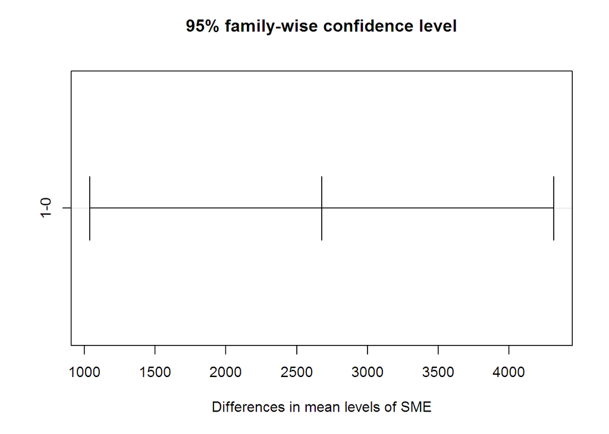

```r
fit.sme %>% TukeyHSD() %>% plot()
```

*Nhận xét:*

- Tính từ 01/2013 - 12/2013: Số lượng khách hàng inactive bình quân mỗi tháng là 9297 khách hàng.
- Tính từ 01/2014 - 12/2015: Số lượng khách hàng bình quân mỗi tháng là 11974 khách hàng.

**Kết luận:** Đủ bằng chứng kết luận rằng, sau khi phân lại tập trung khách hàng từ các phòng giao dịch về các trung tâm SME làm cho số lượng khách hàng inactive tăng.

### 1.3.2 Trước và sau khi phân lại hệ thống dịch vụ chăm sóc khách hàng.

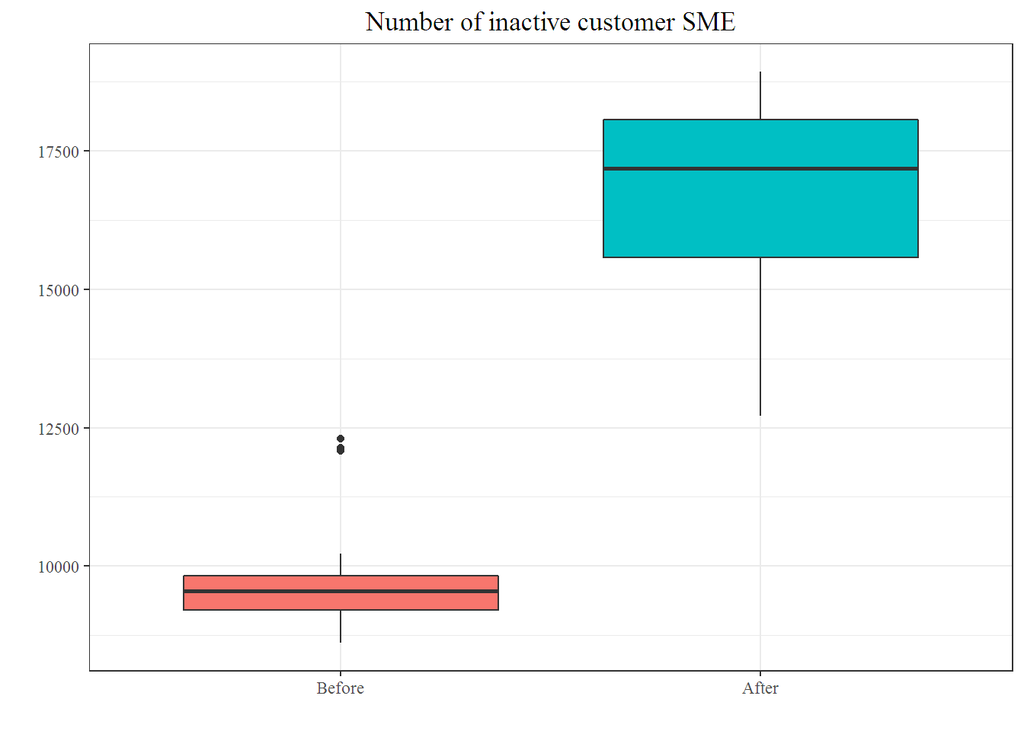

```r
CS <- cus.inactive.total %>%
  filter(REGION %in% c("REGION 1","REGION 2","REGION 3","REGION 4","REGION 5","REGION 6","REGION 7")) %>%
  group_by(Index,Service1) %>%
  summarise(number = n())

CS %>%
  ggplot(aes(Service1,number,fill = Service1))+
  geom_boxplot()+
  theme_bw()+
  theme(legend.position = "none",
        title = element_text(family = "serif"),
        axis.text = element_text(family = "serif"),
         plot.title = element_text(hjust = 0.5))+
  scale_x_discrete(labels = c("0" = "Before","1" = "After"))+
  labs(x= "",
       y= "",
       title = "Number of inactive customer SME")
```

```r
CS %>% group_by(Service1) %>% summarise(mean = mean(number))
```

```
## Source: local data frame [2 x 2]
##
##   Service1      mean
##     (fctr)     (dbl)
## 1        0  9742.926
## 2        1 16684.684
```

```r
fit.cs <- aov(number~Service1,data = CS)
fit.cs %>% summary()
```

```
##             Df    Sum Sq   Mean Sq F value Pr(>F)
## Service1     1 537401047 537401047   273.7 <2e-16 ***
## Residuals   44  86396322   1963553
## ---
## Signif. codes:  0 '***' 0.001 '**' 0.01 '*' 0.05 '.' 0.1 ' ' 1
```

```r
fit.cs %>% TukeyHSD()
```

```
##   Tukey multiple comparisons of means
##     95% family-wise confidence level
##
## Fit: aov(formula = number ~ Service1, data = CS)
##
## $Service1
##         diff      lwr      upr p adj
## 1-0 6941.758 6096.098 7787.418     0
```

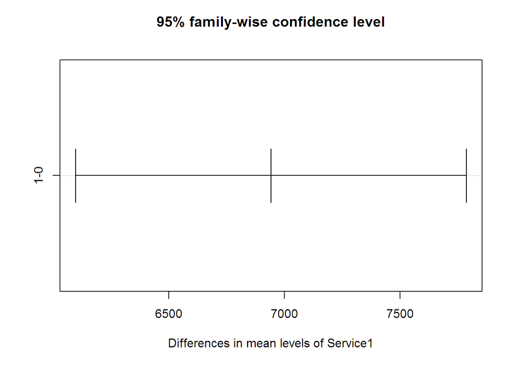

```r
fit.cs %>% TukeyHSD() %>% plot()
```

*Nhận xét:*

- Tính từ 01/2013 - 03/2015 ( Giai đoạn trước khi thay đổi cơ cấu về dịch vụ khách hàng) Số lượng khách hàng inactive bình quân mỗi tháng là 9742 khách hàng
- Tính từ 04/2015 - nay ( Giai đoạn sau khi thay đổi cơ cấu về dịch vụ khách hàng) Số lượng khách hàng inactive bình quân mỗi tháng là 16684 khách hàng

**Kết luận:** Đủ bằng chứng kết luận rằng sau khi thay đổi cơ cấu tổ chức dịch vụ khách hàng tách biệt (KHCN và SME) làm cho số lượng khách hàng inactive của SME tăng.